# Exploratory Data Analysis

STOR 320.01 Group 21

April 05, 2019

# Creator: KEVIN LEE CHEN

### Q1: How does level of education affect pay for H1B immigrant workers?

```r
data <- read_csv("h1data.csv")
wage_data <- data[!is.na(data$PWD_WAGE_RATE),]
ddply(wage_data,~PRIMARY_EDUCATION_LEVEL,summarise,mean=mean(PWD_WAGE_RATE),sd=sd(PWD_WAGE_RATE))
```

```
##       PRIMARY_EDUCATION_LEVEL     mean       sd
## 1                 Associate's 45632.14 13751.67
## 2                  Bachelor's 65755.86 23033.99
## 3             Doctorate (PhD) 51056.80 17895.11
## 4             High School/GED 54175.28 29823.00
## 5                    Master's 69861.80 32404.65
## 6                        None 58133.33 26082.73
## 7 Other Degree (JD, MD, etc.) 91824.45 55562.52
```

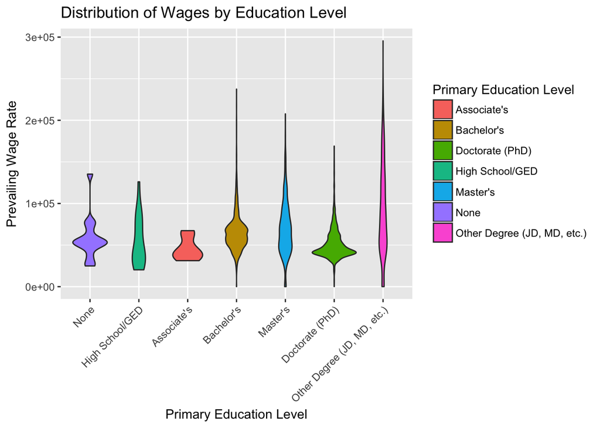

```r
level <- c("None", "High School/GED", "Associate's", "Bachelor's", "Master's", "Doctorate (PhD)", "Other Degree (JD, MD, etc.)")
ggplot(wage_data, aes(factor(PRIMARY_EDUCATION_LEVEL, levels = level), PWD_WAGE_RATE)) +
  geom_violin(aes(fill = factor(PRIMARY_EDUCATION_LEVEL))) +
  ggtitle("Distribution of Wages by Education Level") +
  xlab("Primary Education Level") +
  ylab("Prevailing Wage Rate") +
  labs(fill = "Primary Education Level") +
  theme(axis.text.x=element_text(angle=45, hjust=1))
```

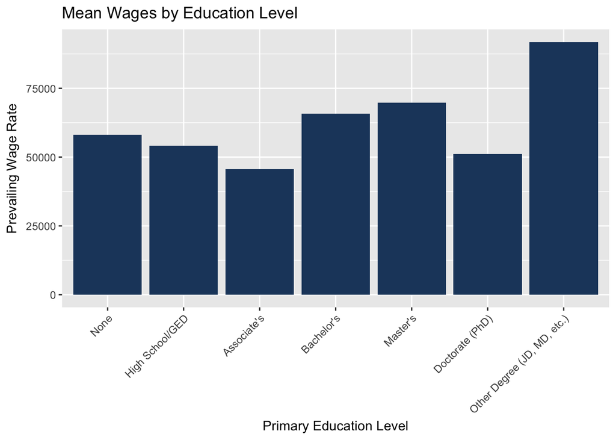

```r
ggplot(wage_data, aes(factor(PRIMARY_EDUCATION_LEVEL, levels = level), PWD_WAGE_RATE)) +
  stat_summary(fun.y="mean", geom="bar", fill = "#20456b") +
  ggtitle("Mean Wages by Education Level") +
  xlab("Primary Education Level") +
  ylab("Prevailing Wage Rate") +
  theme(axis.text.x=element_text(angle=45, hjust=1))
```

### Q2: Are there certain states that see larger amount of immigrant labor?

```r
count <- aggregate(cbind(count = VISA_CLASS) ~ PRIMARY_WORKSITE_STATE,
          data = data,
          FUN = function(x){NROW(x)})
count <- count[-c(8,35,40,48),]
count
```

```
##    PRIMARY_WORKSITE_STATE count
## 1                 ALABAMA    52
## 2                 ARIZONA    61
## 3                ARKANSAS    19
## 4              CALIFORNIA   556
## 5                COLORADO    29
## 6             CONNECTICUT    54
## 7                DELAWARE    36
## 9                 FLORIDA   541
## 10                GEORGIA   181
## 11                 HAWAII    11
## 12                  IDAHO     2
## 13               ILLINOIS   471
## 14                INDIANA   214
## 15                   IOWA    18
```

[output cut: 35 more lines]

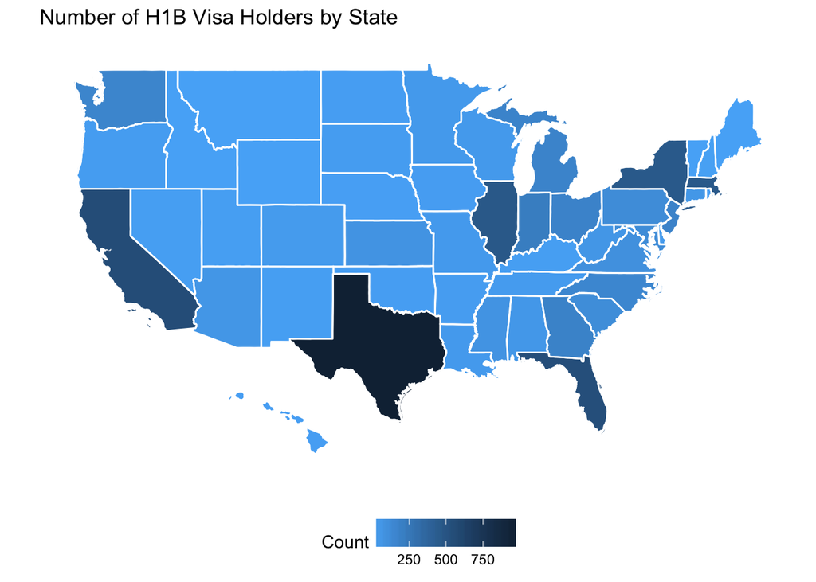

```r
count$PRIMARY_WORKSITE_STATE <- tolower(count$PRIMARY_WORKSITE_STATE)
ggplot(count, aes(map_id = PRIMARY_WORKSITE_STATE)) +
  geom_map(aes(fill = count), map = fifty_states) +
  borders("state", colour = "white") +
  scale_fill_gradient(low = "#56B1F7", high = "#132B43", guide = "colorbar") +
  expand_limits(x = fifty_states$long, y = fifty_states$lat) +
  coord_map() +
  scale_x_continuous(breaks = NULL) +
  scale_y_continuous(breaks = NULL) +
  ggtitle("Number of H1B Visa Holders by State") +
  labs(x = "", y = "", fill = "Count") +
  theme(legend.position = "bottom", panel.background = element_blank())
```

# Interpreter: AMAN DALAL

### Q1: Which companies receive the most H1B applications?

```r
h1b_df  <- read_csv("h1pet.csv")
h1b <- data.frame(lapply(h1b_df, function(v) {
  if (is.factor(v)) return(toupper(v))
  else return(v)
}))
h1b <- tbl_df(h1b)
```

```r
h1b <- h1b %>%
    separate(WORKSITE, c("CITY", "STATE"), ", ")
h1b$STATE <- factor(h1b$STATE, ordered = TRUE)
h1b$YEAR <- factor(h1b$YEAR, ordered = TRUE)

# ggplot(subset(h1b, !is.na(CASE_STATUS)),
#        aes(x = CASE_STATUS, fill = CASE_STATUS)) +
#     geom_bar(stat = "count") +
#     coord_trans(y = "sqrt") +
#     ylab("No. of Applications") +   ggtitle("Distribution of H1B visa case status") +
#     theme(legend.position = c(0.9, 0.9),
#           legend.key.size = unit(0.3, "cm"),
#           legend.title = element_text("Case Status"),
#           axis.text.x=element_text(angle = -10, hjust = 0, size = rel(1)))
```

```r
certified_h1b <- h1b %>%
    filter(CASE_STATUS == "CERTIFIED")
```

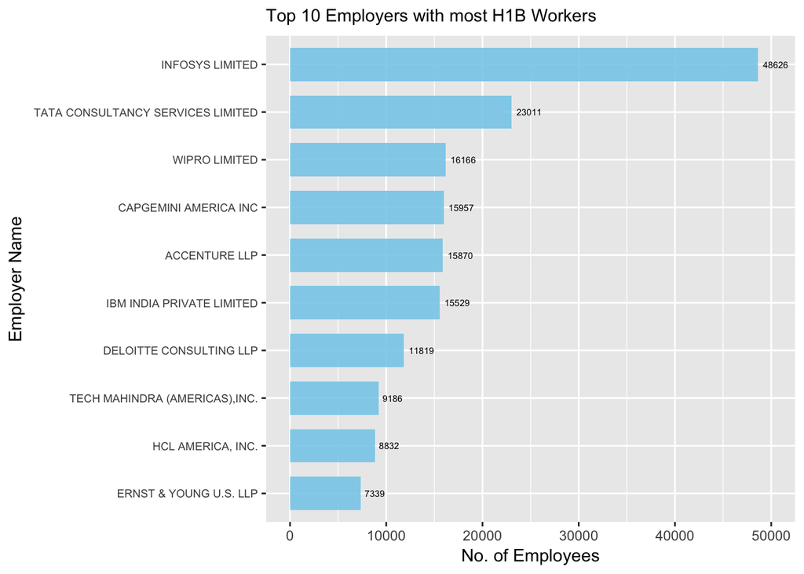

```r
employersMax <- function(num_emp) {
    certified_h1b %>%
        group_by(EMPLOYER_NAME) %>%
        dplyr::summarise(num_apps = n()) %>%
        arrange(desc(num_apps)) %>%
        slice(1:num_emp)
}
ggplot(employersMax(10), aes(x = reorder(EMPLOYER_NAME, num_apps), y = num_apps)) +
    geom_bar(stat = "identity", alpha = 0.9, fill = "sky blue", width = 0.7) +
    labs(x = "Employer Name", y = "No. of Employees") +
    ggtitle("Top 10 Employers with most H1B Workers") +
    geom_text(aes(label = num_apps), hjust = -0.2, size = 2) +
    scale_y_continuous(limits = c(0, 50000), breaks = seq(0, 50000, 10000)) +
    coord_flip() +
    theme(
      axis.text.y = element_text(size = rel(0.8)),
      plot.title = element_text(size = rel(1))
         )
```

### Q2: What range of prevailing wages are expected of the companies that recruit the most H1B visa workers?

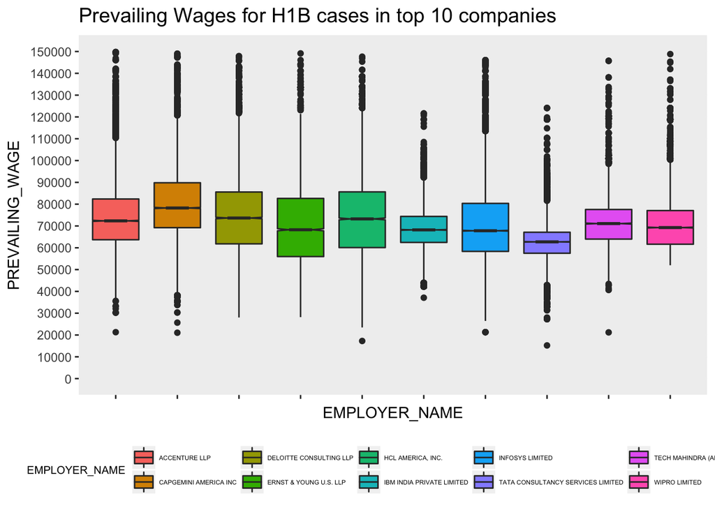

```r
employersTop10 <- certified_h1b %>%
        group_by(EMPLOYER_NAME) %>%
        dplyr::summarise(num_apps = n()) %>%
        arrange(desc(num_apps)) %>%
        slice(1:10) %>%
        select(EMPLOYER_NAME)

employersBoxplotData <- certified_h1b %>%
    filter(EMPLOYER_NAME %in% employersTop10$EMPLOYER_NAME)


ggplot(employersBoxplotData, aes(y = PREVAILING_WAGE, x = EMPLOYER_NAME,
                                 fill = EMPLOYER_NAME, notch = TRUE, notchwidth = .3)) +
      geom_boxplot(notch = TRUE) +
      scale_y_continuous(limits = c(0, 150000),
                         breaks = seq(0, 150000, 10000)) +
       theme(
            panel.grid.major = element_line(colour = '#f0f0f0'),
            plot.title = element_text(size = rel(1.3)),
            panel.background = element_rect(fill = '#f0f0f0'),
            legend.title = element_text(size = rel(0.7)),
            panel.grid.minor = element_line(linetype = 'blank'),
            axis.text.x=element_blank(),
            legend.text = element_text(size = rel(0.4)),
            panel.grid.major.x = element_line(linetype = 'blank'),
            legend.position = "bottom"
      ) +

      ggtitle("Prevailing Wages for H1B cases in top 10 companies")
```

# Orator: ERIC ZHU

### Q1: How do the prevailing wages differ for the different industries that H1B high-skilled immigrants work in?

```r
DATA1=as.tibble(read.csv("h1data.csv"))
names(DATA1)
```

```
##  [1] "VISA_CLASS"                   "BUSINESS_NAME"
##  [3] "EMPLOYER._CITY"               "EMPLOYER._STATE"
##  [5] "EMPLOYER._COUNTRY"            "EMPLOYER._PHONE"
##  [7] "NAICS_CODE"                   "JOB_TITLE"
##  [9] "SUGGESTED._SOC_CODE"          "SUGGESTED_SOC_TITLE"
## [11] "SUPERVISOR_JOB_TITLE"         "SUPERVISE_OTHER_EMP"
## [13] "TRAVEL_REQUIRED"              "PRIMARY_EDUCATION_LEVEL"
## [15] "OTHER_EDUCATION"              "MAJOR"
## [17] "SECOND_DIPLOMA"               "SECOND_DIPLOMA_MAJOR"
## [19] "TRAINING_REQUIRED"            "NUMBER_OF_MONTHS_TRAINING"
## [21] "X"                            "EMP_EXPERIENCE_MONTHS"
## [23] "OCCUPATION_REQUIRED"          "PRIMARY_WORKSITE_CITY"
## [25] "PRIMARY_WORKSITE_COUNTY"      "PRIMARY_WORKSITE_STATE"
## [27] "PRIMARY_WORKSITE_POSTAL_CODE" "OTHER_WORKSITE_LOCATION"
## [29] "WORKSITE_COUNTS"              "PWD_SOC_CODE"
## [31] "PWD_SOC_TITLE"                "PWD_WAGE_RATE"
## [33] "PWD_UNIT_OF_PAY"              "PWD_WAGE_LEVEL"
## [35] "PWD_WAGE_SOURCE"              "PWD_WAGE_EXPIRATION_DATE"
## [37] "SURVEY_PUBLICATION_DATE"
```

```r
Undergrads <- filter(DATA1,PRIMARY_EDUCATION_LEVEL == "Bachelor's")
hourlyUndergrads <- filter(Undergrads, PWD_UNIT_OF_PAY == "Hour")
```

```r
sorted <- DATA1[order(DATA1$SUGGESTED._SOC_CODE) ,]
Industry<-mutate(sorted, industry = substr(sorted$SUGGESTED._SOC_CODE, start =1, stop = 2) )
Industry<-mutate(Industry, subIndustry = substr(sorted$SUGGESTED._SOC_CODE, start =1, stop = 4) )
Industry <- select(Industry, industry, subIndustry, PWD_UNIT_OF_PAY, PWD_WAGE_RATE,SUGGESTED._SOC_CODE,SUGGESTED_SOC_TITLE)
```

```r
groupedIndustry <- dplyr::group_by(Industry, industry)
groupedSubIndustry <- dplyr::group_by(Industry, subIndustry)
countPerIndustry <- dplyr::tally(groupedIndustry)
countPerIndustry <- countPerIndustry[order(countPerIndustry$n), ]
conicalNames <- data.frame(IndustryName = c("Computer and Mathematical Occupations", "Life, Physical, and Social Science Occupations","Educational Instruction and Library Occupations", "Business and Financial Operations Occupations","Architecture and Engineering Occupations","Healthcare Practitioners and Technical Occupations","Management Occupations","Arts, Design, Entertainment, Sports, and Media Occupations","Community and Social Service Occupations","Legal Occupations","Sales and Related Occupations","Office and Administrative Support Occupations"), industry = c(15,19,25,13,17,29,11,27,21,23,41,43))
countPerIndustry <- merge(countPerIndustry, conicalNames, by = "industry", all = TRUE)
summarize(groupedSubIndustry, mean_Salary = mean(PWD_WAGE_RATE, na.rm = TRUE))
```

```
##   mean_Salary
## 1    63999.72
```

```r
meanIndustryWage <- dplyr::summarize(groupedIndustry, mean_Salary = mean(PWD_WAGE_RATE, na.rm = TRUE) )
meanIndustryWage <- merge(meanIndustryWage, countPerIndustry, by = "industry", all= TRUE)
```

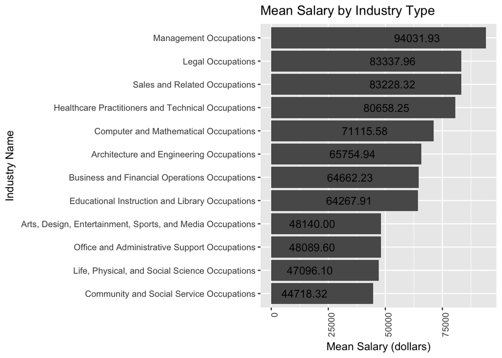

```r
salbyindustry <- ggplot(data=subset(meanIndustryWage, !is.na(meanIndustryWage$IndustryName)),
       mapping=aes(x=reorder(IndustryName,  mean_Salary), y=mean_Salary),
       na.rm=TRUE) +
  coord_flip() +
  geom_col() +
  geom_text(aes(label=sprintf("%0.2f", round(mean_Salary, digits = 2))), position=position_dodge(width=.5), vjust= .5, hjust = 2) +
  theme(axis.text.x = element_text(angle = 90, hjust = 1)) +
  labs(title = "Mean Salary by Industry Type",
       y = "Mean Salary (dollars)",
       x = "Industry Name")
salbyindustry
```

### Q1: Are certain industries more common for H1B visa workers?

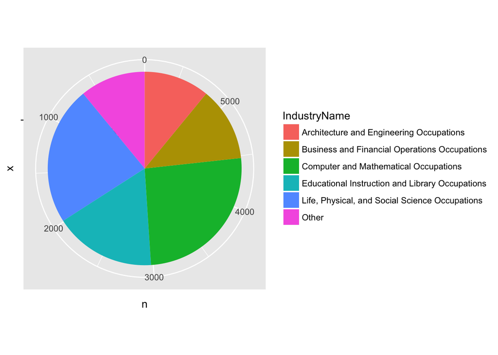

```r
df <- subset(meanIndustryWage, !is.na(meanIndustryWage$IndustryName))
df <- df %>%
  arrange(desc(n)) %>%
  slice(1:5) %>%
  select(n, IndustryName)
other <-  df %>%
  arrange(desc(n)) %>%
  slice(6:nrow(df))
other <- other %>%
  summarise(n=sum(n),
            IndustryName='Other')
final <- rbind(df, other)
ggplot(final, aes(x = "", y = n, fill = IndustryName)) +
  geom_text(aes(label= as.character(n))) +
  geom_col(width = 1) +
  coord_polar("y", direction = -1)
```

# Deliverer: EVAN VIKTUS

### Q1: Is there any seasonality behind when immigrants are applying/getting their determination wage?

```r
library(rvest)
library(lubridate)
finalP = read_csv("PWD_Disclosure_Data_FY2018_EOY.csv")
finalP <- separate(finalP,SUBMIT_DATE,into=c("Submit_Date", "Submit_Time"),sep=" ")
finalP <- separate(finalP,DETERMINATION_DATE,into=c("Determin_Date", "Determin_Time"),sep=" ")
finalP$Submit_Date <- as.Date(finalP$Submit_Date, format = c("%m/%d/%Y"))
finalP$Determin_Date <- as.Date(finalP$Determin_Date, format = c("%m/%d/%Y"))
```

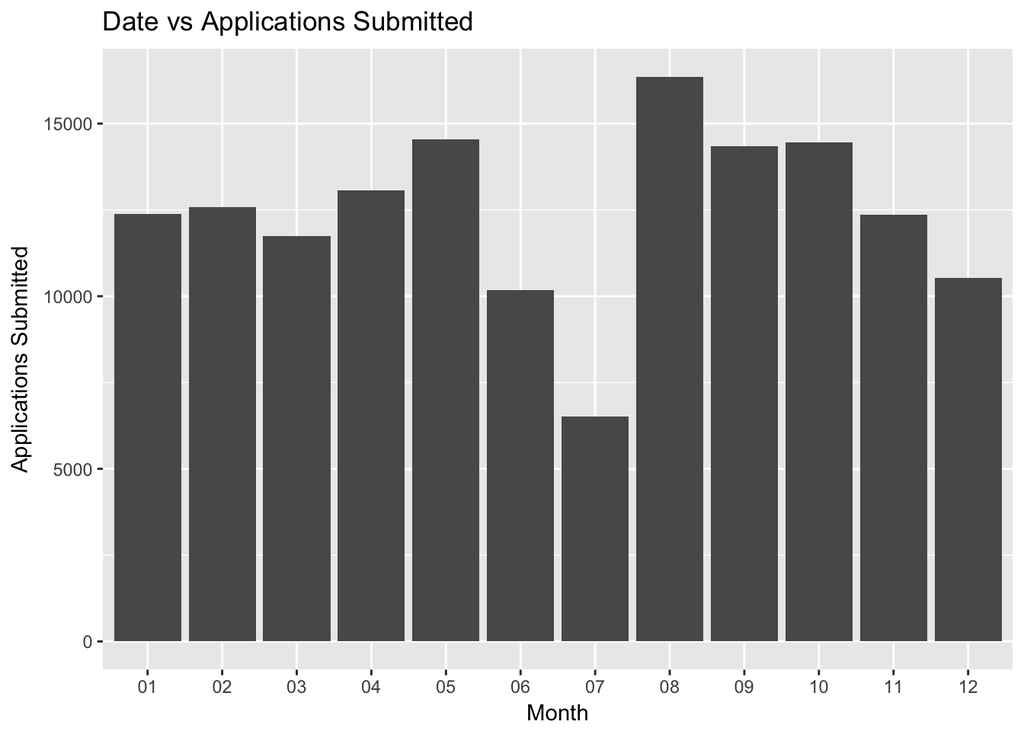

```r
finalP2 <- subset(finalP, !is.na(finalP$Submit_Date))
finalP3 <- subset(finalP, !is.na(finalP$Determin_Date))
ggplot(finalP2) + geom_bar(mapping = aes(format(finalP2$Submit_Date,"%m"))) + xlab("Month") + ylab("Applications Submitted") + ggtitle("Date vs Applications Submitted")
```

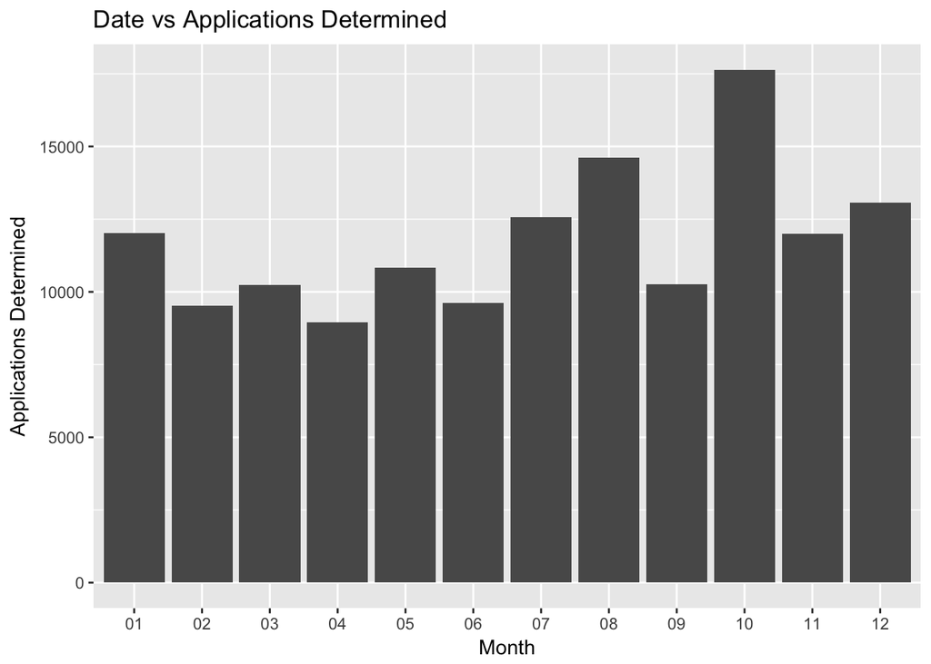

```r
ggplot(finalP3) + geom_bar(mapping = aes(format(finalP3$Determin_Date,"%m"))) + xlab("Month") + ylab("Applications Determined") + ggtitle("Date vs Applications Determined")
```

### Q2: Do supervisors receive higher pay than none supervisors?

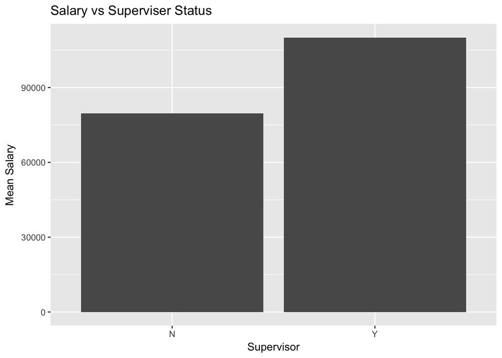

```r
salD <- ddply(finalP,~SUPERVISE_OTHER_EMP,summarise, sal = mean(PWD_WAGE_RATE, na.rm = TRUE))
ggplot(data = salD, mapping = aes(x = SUPERVISE_OTHER_EMP, y = sal)) +  geom_col() + xlab("Supervisor") + ylab("Mean Salary") + ggtitle("Salary vs Superviser Status")
```

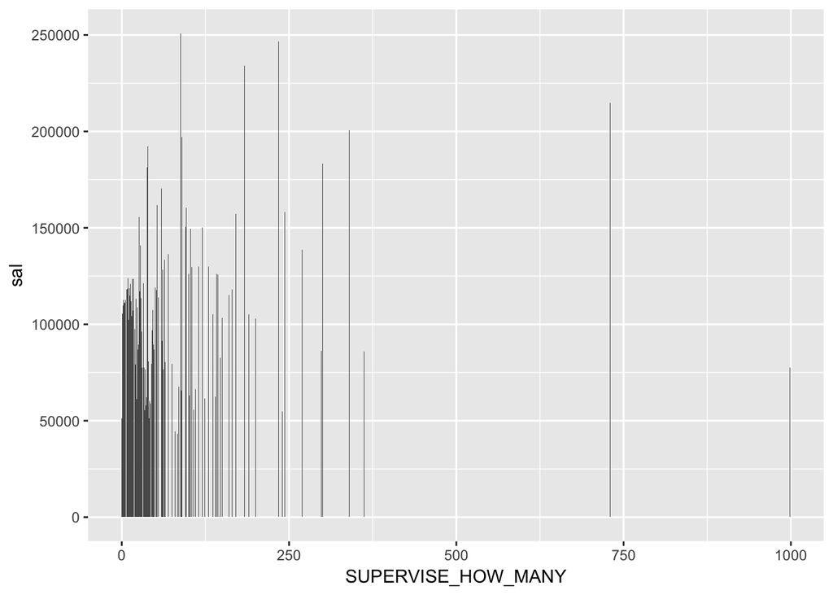

```r
salD <- ddply(finalP,~SUPERVISE_HOW_MANY,summarise, sal = mean(PWD_WAGE_RATE, na.rm = TRUE))
ggplot(data = salD, mapping = aes(x = SUPERVISE_HOW_MANY, y = sal)) +  geom_col()
```

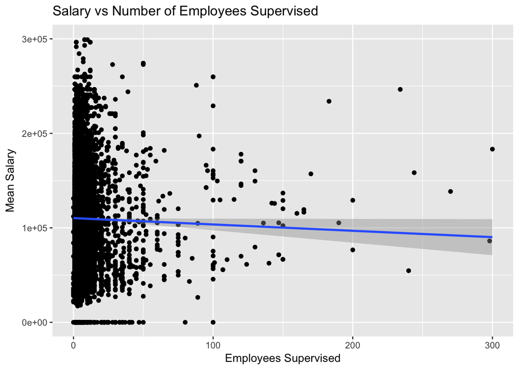

```r
ggplot(data = finalP, mapping = aes(x = SUPERVISE_HOW_MANY, y = PWD_WAGE_RATE)) +  geom_point() +  geom_smooth(se = TRUE, method = "lm") + xlab("Employees Supervised") + ylab("Mean Salary") + ggtitle("Salary vs Number of Employees Supervised") +xlim(0, 300)+ylim(0, 300000)
```

# Follow-up Questions

### New Questions Based Off Initial Investigation

Q1: Does the base salary of the job listing for the H1B visa application affect the chances of the visa being certified or denied? (Aman)

Q2: What is the relationship between occupation type and the state that a visa is granted in? (Kevin)

Q3: Does the average length of time between determination date and submission date change depending on the initial submission month? Is the difference more strongly related to a different variable? (Evan)

Q4: How was the median salary of the H1B visa workers changed over the past decade? (Eric)

Q5: In the states with the most H1B visa workers, what cities are these employees most concentrated in?

### Investigation of Follow-up Questions

Our group decided to investigate Q1 and Q3 in further detail.

### Q3: Does the average length of time between determination date and submission date change depending on the initial submission month? Is the difference more strongly related to a different variable? (Evan)

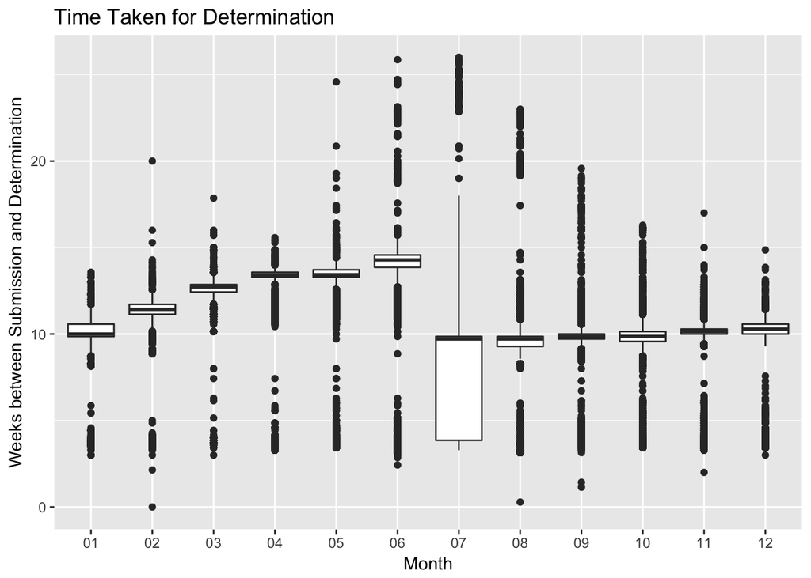

```r
finalP$diffDate = difftime(finalP$Determin_Date,finalP$Submit_Date,units='weeks')
finalP4 <- subset(finalP, !is.na(finalP$diffDate))
finalP4 <- subset(finalP, !is.na(finalP$Submit_Date))
finalP4$subMonth = format(finalP2$Submit_Date,"%m")
ggplot(finalP4) + geom_boxplot(mapping = aes(x = subMonth, y = diffDate)) + xlab("Month") + ylab("Weeks between Submission and Determination") + ggtitle("Time Taken for Determination")
```

### Q1: Does the base salary of the job listing for the H1B visa application affect the chances of the visa being certified or denied? (Aman)

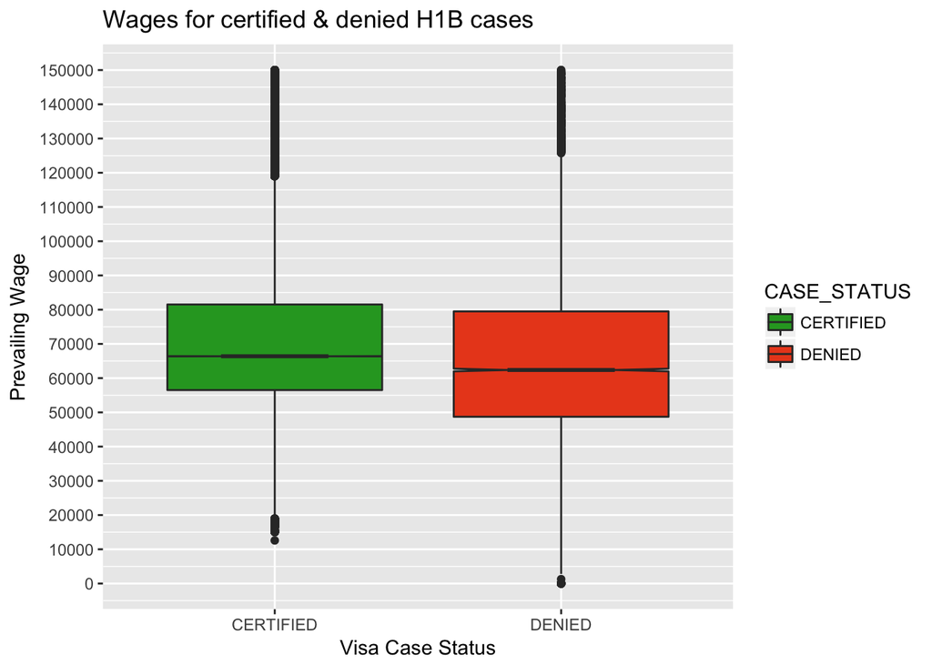

```r
certified_denied_h1b <- h1b %>%
    filter(CASE_STATUS == "CERTIFIED" | CASE_STATUS == "DENIED")

ggplot(certified_denied_h1b, aes(y = PREVAILING_WAGE, x = CASE_STATUS,
                                 fill = CASE_STATUS, notch = TRUE,
                                 notchwidth = .3)) +
      xlab("Visa Case Status") + ylab("Prevailing Wage") +
      ggtitle("Wages for certified & denied H1B cases") +
      scale_y_continuous(breaks = seq(0, 150000, 10000),
                         limits = c(0, 150000)) +
      geom_boxplot(notch = TRUE)+
      scale_fill_manual(values = c("#29a329", "#ea4b1f"))
```

# Summary

Follow Up Investigation

For our first investigation we graphed the amount of time it took each Visa to be determined (reach a decision on the application) based on month the submitted. We can see a steep drop off in time in the month of July. The number of applications also decreased during the month so the decrease in time could be attributed to fewer applicants but we could investigate further to see if other variables are affecting the determination time. Our second investigation dived deeper into the prevailing wages of H1B cases to understand whether there is a relationship between the prevailing wage for a certain employment oppurtunity and whether or not the H1B worker tied to the job has his or her application denied or approved by USCIS. Although the median prevailing wage for Certified H1B applications is slightly higher, the distributions of the wages for Certified and Denied applications are quite similar. We could investigate further using linear regression between the variables to develop a stronger conclusion but with the current figures it is not possible to conclude there is relationship between the prevailing wage of a H1B job application and whether it is certified or denied.